# Project: Investigate a Dataset - [No-show appointments analysis]

- Introduction
- Data Wrangling
- Exploratory Data Analysis
- Conclusions

## Introduction

### Dataset Description

In this project I will be analyzing medical appointments in Brazil which focused on the question of whether or not patients show up for their appointment as scheduled. I will be using No-show appointment's dataframe gotten from Kaggle for the analysis. The dataframe has significant table columns which are: (1) Patient_id that shows a Unique identifier for the patient. (2) Appointment_id which shows Unique identifier for the appointment. (3) Gender shows Gender of the patient in the dataset. (4) Scheduled day: shows the date appointment was scheduled (5) Appointment day: shows appointment date and time. (6) Age: shows patient age. (7) Neighborhood: Neighborhood hospital is located. (8) Scholarship: the column indicate whether or not the patient enrolled in Brasilian welfare program. The dataframe also contains columns that narrate type of patients illness. (9) Hypertension: One (1) indicate that the patient is Hypertensive while zero (0) indicate not. (10) Diabetes: One (1) indicate that the patient is Diabetics while zero (0) indicate not. (11) Alcoholism: One (1) indicate that the patient have Alcoholism while zero (0) indicate not. (12) Handicap: (1) indicate that the patient is Handicap while zero (0) indicate not. Other columns are: (13) SMS received: One (1) indicate that the patient have received notification while zero (0) indicate not. (14) No_show: NO if patient show for the appointment while YES indicate not.

### Question(s) for Analysis

1. what is the effect of elapsed time(day interval between Scheduled day and Appointment day) to not show up for scheduled appointment?
2. What factors are important for us to know in order to predict if a patient will show up for their scheduled appointment?

```python
import pandas as pd
import numpy as np
import matplotlib.pyplot as plt
import seaborn as sns
%matplotlib inline
```

```python
# Upgrade pandas to use dataframe.explode() function.
!pip install --upgrade pandas==0.25.0
```

## Data Wrangling

```python
# Loading data and printing out a few lines.
No_show_df= pd.read_csv('noshowappointments-kagglev2-may-2016.csv')
No_show_df.head()
```

|  | PatientId | AppointmentID | Gender | ScheduledDay | AppointmentDay | Age | Neighbourhood | Scholarship | Hipertension | Diabetes | Alcoholism | Handcap | SMS_received | No-show |
| --- | --- | --- | --- | --- | --- | --- | --- | --- | --- | --- | --- | --- | --- | --- |
| 0 | 2.987250e+13 | 5642903 | F | 2016-04-29T18:38:08Z | 2016-04-29T00:00:00Z | 62 | JARDIM DA PENHA | 0 | 1 | 0 | 0 | 0 | 0 | No |
| 1 | 5.589978e+14 | 5642503 | M | 2016-04-29T16:08:27Z | 2016-04-29T00:00:00Z | 56 | JARDIM DA PENHA | 0 | 0 | 0 | 0 | 0 | 0 | No |
| 2 | 4.262962e+12 | 5642549 | F | 2016-04-29T16:19:04Z | 2016-04-29T00:00:00Z | 62 | MATA DA PRAIA | 0 | 0 | 0 | 0 | 0 | 0 | No |
| 3 | 8.679512e+11 | 5642828 | F | 2016-04-29T17:29:31Z | 2016-04-29T00:00:00Z | 8 | PONTAL DE CAMBURI | 0 | 0 | 0 | 0 | 0 | 0 | No |
| 4 | 8.841186e+12 | 5642494 | F | 2016-04-29T16:07:23Z | 2016-04-29T00:00:00Z | 56 | JARDIM DA PENHA | 0 | 1 | 1 | 0 | 0 | 0 | No |

```python
#investigating dataset- row and column
No_show_df.shape
```

```
(110527, 14)
```

```python
# checking for missing data & data type
No_show_df.info()
```

```
<class 'pandas.core.frame.DataFrame'>
RangeIndex: 110527 entries, 0 to 110526
Data columns (total 14 columns):
 #   Column          Non-Null Count   Dtype
---  ------          --------------   -----
 0   PatientId       110527 non-null  float64
 1   AppointmentID   110527 non-null  int64
 2   Gender          110527 non-null  object
 3   ScheduledDay    110527 non-null  object
 4   AppointmentDay  110527 non-null  object
 5   Age             110527 non-null  int64
 6   Neighbourhood   110527 non-null  object
 7   Scholarship     110527 non-null  int64
 8   Hipertension    110527 non-null  int64
 9   Diabetes        110527 non-null  int64
 10  Alcoholism      110527 non-null  int64
 11  Handcap         110527 non-null  int64
 12  SMS_received    110527 non-null  int64
 13  No-show         110527 non-null  object
dtypes: float64(1), int64(8), object(5)
memory usage: 11.8+ MB
```

```python
#checking for duplicate in the dataset
sum(No_show_df.duplicated())
```

```
0
```

```python
#checking the statistical analysis of the dataset
No_show_df.describe()
```

|  | PatientId | AppointmentID | Age | Scholarship | Hipertension | Diabetes | Alcoholism | Handcap | SMS_received |
| --- | --- | --- | --- | --- | --- | --- | --- | --- | --- |
| count | 1.105270e+05 | 1.105270e+05 | 110527.000000 | 110527.000000 | 110527.000000 | 110527.000000 | 110527.000000 | 110527.000000 | 110527.000000 |
| mean | 1.474963e+14 | 5.675305e+06 | 37.088874 | 0.098266 | 0.197246 | 0.071865 | 0.030400 | 0.022248 | 0.321026 |
| std | 2.560949e+14 | 7.129575e+04 | 23.110205 | 0.297675 | 0.397921 | 0.258265 | 0.171686 | 0.161543 | 0.466873 |
| min | 3.921784e+04 | 5.030230e+06 | -1.000000 | 0.000000 | 0.000000 | 0.000000 | 0.000000 | 0.000000 | 0.000000 |
| 25% | 4.172614e+12 | 5.640286e+06 | 18.000000 | 0.000000 | 0.000000 | 0.000000 | 0.000000 | 0.000000 | 0.000000 |
| 50% | 3.173184e+13 | 5.680573e+06 | 37.000000 | 0.000000 | 0.000000 | 0.000000 | 0.000000 | 0.000000 | 0.000000 |
| 75% | 9.439172e+13 | 5.725524e+06 | 55.000000 | 0.000000 | 0.000000 | 0.000000 | 0.000000 | 0.000000 | 1.000000 |
| max | 9.999816e+14 | 5.790484e+06 | 115.000000 | 1.000000 | 1.000000 | 1.000000 | 1.000000 | 4.000000 | 1.000000 |

```python
#investigating negative in the age.
No_show_df[No_show_df['Age'].astype(str).str.contains('-')]
```

|  | PatientId | AppointmentID | Gender | ScheduledDay | AppointmentDay | Age | Neighbourhood | Scholarship | Hipertension | Diabetes | Alcoholism | Handcap | SMS_received | No-show |
| --- | --- | --- | --- | --- | --- | --- | --- | --- | --- | --- | --- | --- | --- | --- |
| 99832 | 4.659432e+14 | 5775010 | F | 2016-06-06T08:58:13Z | 2016-06-06T00:00:00Z | -1 | ROMÃO | 0 | 0 | 0 | 0 | 0 | 0 | No |

The data was investigated and i discovered that the data cointains 110527 rows and 14 columns. The dataset doesnt have missing value and has no duplicated cell. ScheduledDay and AppointmentDay columns are in object data type and needs to be change to datetime format to replicate date and time. it was noticed that age column contain a negative value -1 year of age, this is not rational but have less effect on the analysis because the No_show column contain a useful value on the patient . Lastle, i noticed some columns names are match togrther without space.

### Data Cleaning

```python
No_show_df.drop(['AppointmentID'], axis = 1, inplace = True)
```

I dropped AppointmentID which is not relevant to my analysis and for clear visualization

```python
No_show_df= No_show_df.rename(columns={'PatientId': 'Patient_Id', 'ScheduledDay': 'Scheduled_Day', 'AppointmentDay': 'Appointment_Day', 'No-show': 'No_show'})
No_show_df.head()
```

|  | Patient_Id | Gender | Scheduled_Day | Appointment_Day | Age | Neighbourhood | Scholarship | Hipertension | Diabetes | Alcoholism | Handcap | SMS_received | No_show |
| --- | --- | --- | --- | --- | --- | --- | --- | --- | --- | --- | --- | --- | --- |
| 0 | 2.987250e+13 | F | 2016-04-29T18:38:08Z | 2016-04-29T00:00:00Z | 62 | JARDIM DA PENHA | 0 | 1 | 0 | 0 | 0 | 0 | No |
| 1 | 5.589978e+14 | M | 2016-04-29T16:08:27Z | 2016-04-29T00:00:00Z | 56 | JARDIM DA PENHA | 0 | 0 | 0 | 0 | 0 | 0 | No |
| 2 | 4.262962e+12 | F | 2016-04-29T16:19:04Z | 2016-04-29T00:00:00Z | 62 | MATA DA PRAIA | 0 | 0 | 0 | 0 | 0 | 0 | No |
| 3 | 8.679512e+11 | F | 2016-04-29T17:29:31Z | 2016-04-29T00:00:00Z | 8 | PONTAL DE CAMBURI | 0 | 0 | 0 | 0 | 0 | 0 | No |
| 4 | 8.841186e+12 | F | 2016-04-29T16:07:23Z | 2016-04-29T00:00:00Z | 56 | JARDIM DA PENHA | 0 | 1 | 1 | 0 | 0 | 0 | No |

I renamed some columns for clearity and easy assessment

```python
No_show_df['Scheduled_Day']= pd.to_datetime(No_show_df['Scheduled_Day'])
No_show_df['Appointment_Day']= pd.to_datetime(No_show_df['Appointment_Day'])
No_show_df.info()
```

```
<class 'pandas.core.frame.DataFrame'>
RangeIndex: 110527 entries, 0 to 110526
Data columns (total 13 columns):
 #   Column           Non-Null Count   Dtype
---  ------           --------------   -----
 0   Patient_Id       110527 non-null  float64
 1   Gender           110527 non-null  object
 2   Scheduled_Day    110527 non-null  datetime64[ns, UTC]
 3   Appointment_Day  110527 non-null  datetime64[ns, UTC]
 4   Age              110527 non-null  int64
 5   Neighbourhood    110527 non-null  object
 6   Scholarship      110527 non-null  int64
 7   Hipertension     110527 non-null  int64
 8   Diabetes         110527 non-null  int64
 9   Alcoholism       110527 non-null  int64
 10  Handcap          110527 non-null  int64
 11  SMS_received     110527 non-null  int64
 12  No_show          110527 non-null  object
dtypes: datetime64[ns, UTC](2), float64(1), int64(7), object(3)
memory usage: 11.0+ MB
```

I changed Appointment_Day and Scheduled_Day from object datatype to datetime datatype for proper analysis

```python
No_show_df["Appointment_to_Schedule_date"] = (No_show_df['Appointment_Day'] - No_show_df['Scheduled_Day'].apply(lambda x : x.replace(minute=0, hour=0, second=0, microsecond=0))).apply(lambda x: x.days)
No_show_df.info()
```

```
<class 'pandas.core.frame.DataFrame'>
RangeIndex: 110527 entries, 0 to 110526
Data columns (total 14 columns):
 #   Column                        Non-Null Count   Dtype
---  ------                        --------------   -----
 0   Patient_Id                    110527 non-null  float64
 1   Gender                        110527 non-null  object
 2   Scheduled_Day                 110527 non-null  datetime64[ns, UTC]
 3   Appointment_Day               110527 non-null  datetime64[ns, UTC]
 4   Age                           110527 non-null  int64
 5   Neighbourhood                 110527 non-null  object
 6   Scholarship                   110527 non-null  int64
 7   Hipertension                  110527 non-null  int64
 8   Diabetes                      110527 non-null  int64
 9   Alcoholism                    110527 non-null  int64
 10  Handcap                       110527 non-null  int64
 11  SMS_received                  110527 non-null  int64
 12  No_show                       110527 non-null  object
 13  Appointment_to_Schedule_date  110527 non-null  int64
dtypes: datetime64[ns, UTC](2), float64(1), int64(8), object(3)
memory usage: 11.8+ MB
```

I created an additional column to show the day diffrent of the Scheduled_Day and the Appointment Date. This column was created so as for me to analyse the effect of elapsed time on the attitute of patients towards their scheduled appointment.

```python
No_show_df['No_show']= No_show_df['No_show'].map({'Yes':0, 'No':1})
No_show_df.head()
```

|  | Patient_Id | Gender | Scheduled_Day | Appointment_Day | Age | Neighbourhood | Scholarship | Hipertension | Diabetes | Alcoholism | Handcap | SMS_received | No_show | Appointment_to_Schedule_date |
| --- | --- | --- | --- | --- | --- | --- | --- | --- | --- | --- | --- | --- | --- | --- |
| 0 | 2.987250e+13 | F | 2016-04-29 18:38:08+00:00 | 2016-04-29 00:00:00+00:00 | 62 | JARDIM DA PENHA | 0 | 1 | 0 | 0 | 0 | 0 | 1 | 0 |
| 1 | 5.589978e+14 | M | 2016-04-29 16:08:27+00:00 | 2016-04-29 00:00:00+00:00 | 56 | JARDIM DA PENHA | 0 | 0 | 0 | 0 | 0 | 0 | 1 | 0 |
| 2 | 4.262962e+12 | F | 2016-04-29 16:19:04+00:00 | 2016-04-29 00:00:00+00:00 | 62 | MATA DA PRAIA | 0 | 0 | 0 | 0 | 0 | 0 | 1 | 0 |
| 3 | 8.679512e+11 | F | 2016-04-29 17:29:31+00:00 | 2016-04-29 00:00:00+00:00 | 8 | PONTAL DE CAMBURI | 0 | 0 | 0 | 0 | 0 | 0 | 1 | 0 |
| 4 | 8.841186e+12 | F | 2016-04-29 16:07:23+00:00 | 2016-04-29 00:00:00+00:00 | 56 | JARDIM DA PENHA | 0 | 1 | 1 | 0 | 0 | 0 | 1 | 0 |

```python
No_show_df.shape
```

```
(110527, 14)
```

```python
No_show_df.describe()
```

|  | Patient_Id | Age | Scholarship | Hipertension | Diabetes | Alcoholism | Handcap | SMS_received | No_show | Appointment_to_Schedule_date |
| --- | --- | --- | --- | --- | --- | --- | --- | --- | --- | --- |
| count | 1.105270e+05 | 110527.000000 | 110527.000000 | 110527.000000 | 110527.000000 | 110527.000000 | 110527.000000 | 110527.000000 | 110527.000000 | 110527.000000 |
| mean | 1.474963e+14 | 37.088874 | 0.098266 | 0.197246 | 0.071865 | 0.030400 | 0.022248 | 0.321026 | 0.798067 | 10.183702 |
| std | 2.560949e+14 | 23.110205 | 0.297675 | 0.397921 | 0.258265 | 0.171686 | 0.161543 | 0.466873 | 0.401444 | 15.254996 |
| min | 3.921784e+04 | -1.000000 | 0.000000 | 0.000000 | 0.000000 | 0.000000 | 0.000000 | 0.000000 | 0.000000 | -6.000000 |
| 25% | 4.172614e+12 | 18.000000 | 0.000000 | 0.000000 | 0.000000 | 0.000000 | 0.000000 | 0.000000 | 1.000000 | 0.000000 |
| 50% | 3.173184e+13 | 37.000000 | 0.000000 | 0.000000 | 0.000000 | 0.000000 | 0.000000 | 0.000000 | 1.000000 | 4.000000 |
| 75% | 9.439172e+13 | 55.000000 | 0.000000 | 0.000000 | 0.000000 | 0.000000 | 0.000000 | 1.000000 | 1.000000 | 15.000000 |
| max | 9.999816e+14 | 115.000000 | 1.000000 | 1.000000 | 1.000000 | 1.000000 | 4.000000 | 1.000000 | 1.000000 | 179.000000 |

```python
No_show_df[No_show_df['Appointment_to_Schedule_date'].astype(str).str.contains('-')]
```

|  | Patient_Id | Gender | Scheduled_Day | Appointment_Day | Age | Neighbourhood | Scholarship | Hipertension | Diabetes | Alcoholism | Handcap | SMS_received | No_show | Appointment_to_Schedule_date |
| --- | --- | --- | --- | --- | --- | --- | --- | --- | --- | --- | --- | --- | --- | --- |
| 27033 | 7.839273e+12 | M | 2016-05-10 10:51:53+00:00 | 2016-05-09 00:00:00+00:00 | 38 | RESISTÊNCIA | 0 | 0 | 0 | 0 | 1 | 0 | 0 | -1 |
| 55226 | 7.896294e+12 | F | 2016-05-18 14:50:41+00:00 | 2016-05-17 00:00:00+00:00 | 19 | SANTO ANTÔNIO | 0 | 0 | 0 | 0 | 1 | 0 | 0 | -1 |
| 64175 | 2.425226e+13 | F | 2016-05-05 13:43:58+00:00 | 2016-05-04 00:00:00+00:00 | 22 | CONSOLAÇÃO | 0 | 0 | 0 | 0 | 0 | 0 | 0 | -1 |
| 71533 | 9.982316e+14 | F | 2016-05-11 13:49:20+00:00 | 2016-05-05 00:00:00+00:00 | 81 | SANTO ANTÔNIO | 0 | 0 | 0 | 0 | 0 | 0 | 0 | -6 |
| 72362 | 3.787482e+12 | M | 2016-05-04 06:50:57+00:00 | 2016-05-03 00:00:00+00:00 | 7 | TABUAZEIRO | 0 | 0 | 0 | 0 | 0 | 0 | 0 | -1 |

```python
No_show_df= No_show_df[No_show_df["Appointment_to_Schedule_date"].astype(str).str.contains("-") == False]
```

After cleaning the dataset i discovered in the 'Appointment_to_Schedule_date' column created that some patient scheduled date was after the appointment date, this doesnt look normal and i investigated futher. Five rows was discovered to be having the issues and i decided to drop them so as for them not to distort my analysis

```python
No_show_df.shape
```

```
(110522, 14)
```

```python
No_show_df.info()
```

```
<class 'pandas.core.frame.DataFrame'>
Int64Index: 110522 entries, 0 to 110526
Data columns (total 14 columns):
 #   Column                        Non-Null Count   Dtype
---  ------                        --------------   -----
 0   Patient_Id                    110522 non-null  float64
 1   Gender                        110522 non-null  object
 2   Scheduled_Day                 110522 non-null  datetime64[ns, UTC]
 3   Appointment_Day               110522 non-null  datetime64[ns, UTC]
 4   Age                           110522 non-null  int64
 5   Neighbourhood                 110522 non-null  object
 6   Scholarship                   110522 non-null  int64
 7   Hipertension                  110522 non-null  int64
 8   Diabetes                      110522 non-null  int64
 9   Alcoholism                    110522 non-null  int64
 10  Handcap                       110522 non-null  int64
 11  SMS_received                  110522 non-null  int64
 12  No_show                       110522 non-null  int64
 13  Appointment_to_Schedule_date  110522 non-null  int64
dtypes: datetime64[ns, UTC](2), float64(1), int64(9), object(2)
memory usage: 12.6+ MB
```

## Exploratory Data Analysis

### Research Question 1 (Analysis of the effect of elapsed time on not showing up for scheduled appointment)

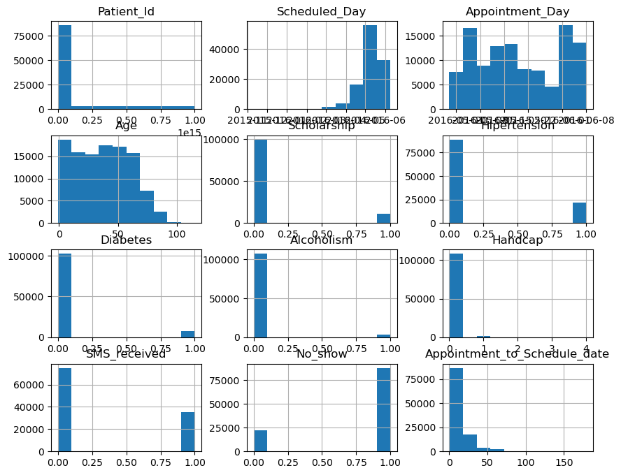

```python
No_show_df.hist(figsize=(10,8));
```

The histogram of all the dataset columns

```python
show = No_show_df.No_show == False
No_show = No_show_df.No_show == True
```

Creation of rows for patient that shows for their appointments and those that did not.

```python
No_show_df.Appointment_to_Schedule_date[show].mean()
```

```
15.835484449224701
```

```python
No_show_df.Appointment_to_Schedule_date[No_show].mean()
```

```
8.754659441320515
```

[figure not shown]

```python
No_show_df.Appointment_to_Schedule_date[show].hist(alpha=0.8, bins=25, label='showed')
No_show_df.Appointment_to_Schedule_date[No_show].hist(alpha=0.5, bins=25, label='Not_show')
plt.title("Effect of the elapsed time on No_show")
plt.legend();
```

### Research Question 2 (Factors that are important for us to know how to predict if a patient will show up for their scheduled appointment)

To determine factors to predict if patient will show up for their appointments, i will be testing the Gender , Age, Scholarship and SMS_received against No_show column to see the effect of this factors on the attitude of the patients to their appointments.

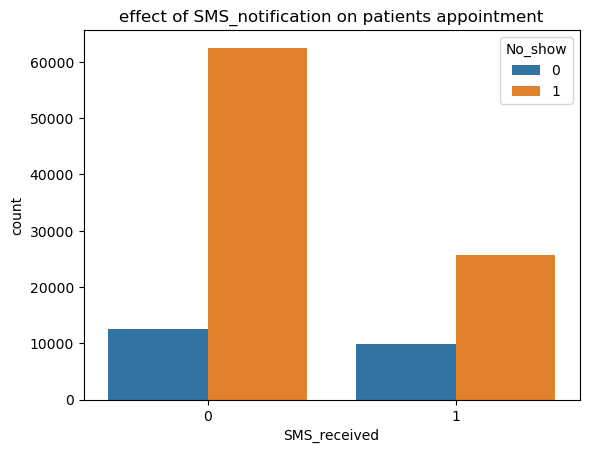

```python
sns.countplot(x="SMS_received", hue="No_show", data=No_show_df)
plt.title("effect of SMS_notification on patients appointment")
plt.show()
```

[figure not shown]

```python
No_show_df.Age[show].hist(alpha=0.5, bins=25, label='showed')
No_show_df.Age[No_show].hist(alpha=0.5, bins=25, label='Not_show')
plt.title("Effect of the patients age on No_show")
plt.legend();
```

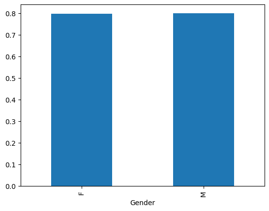

```python
No_show_df.groupby('Gender').No_show.mean().plot(kind='bar');
```

The analysis using Bar chart, focused on the effect of Gender on the attitudes of patients towards their scheduled appointment. Thus, the independent variable is No_show column that indicate whether the patient show's up for their appointment or not and the dependent variable is the patient gender. The chart shows that Male and Female patient react almost same to the appointment. This indicate that gender have no effect on the reaction of the patients to appointments

```python
No_show_df.Gender.value_counts()
```

```
F    71837
M    38685
Name: Gender, dtype: int64
```

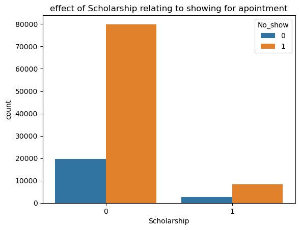

```python
sns.countplot(x="Scholarship", hue="No_show", data=No_show_df)
plt.title("effect of Scholarship relating to showing for apointment")
plt.show()
```

The analysis using Bar chart, focused on the effect of scholarship on the attitudes of patients towards their scheduled appointment. Thus, the independent variable is No_show column that indicate whether the patient show's up for their appointment or not and the dependent variable is the scholarship which indicate whether or not the patient enrolled in Brasilian welfare program. Bar chart shows that scholarship does not have effect on the patient attitude towards showing up for the appointment. Patient with scholarship that showed (represent by 1) is far lower than those without scholarship that do not show (represent by 0)

## Conclusions

With the summary above, factors to considered while predicting whether or not patient will show up for their appointments are elapsed time, age and SMS received.

For futher and more detailed prediction, information containing the history of the patients on showing up for the appointment is neccessary and also, patients house location to determine whether patient distance to the hospital is one of the factors or not.

Limitation

(1) No use of machine learning and infrential statistics is a big limitation in this project because it deny me from having a well detailed interpretation of the visualisation to draw conclusions. (2) Having some value in the dataset which are very difficult to drop because the row have some useful value needed for the project i.e having negative value in the age column.

```python
from subprocess import call
call(['python', '-m', 'nbconvert', 'Investigate_a_Dataset.ipynb'])
```